# Transforming and adjusting time series

## The ABS stuff-up

```r
dcmp <- employed |>
  filter(Year >= 2005) |>
  model(stl = STL(Employed ~ season(window = 11), robust = TRUE))
components(dcmp) |> autoplot()
```

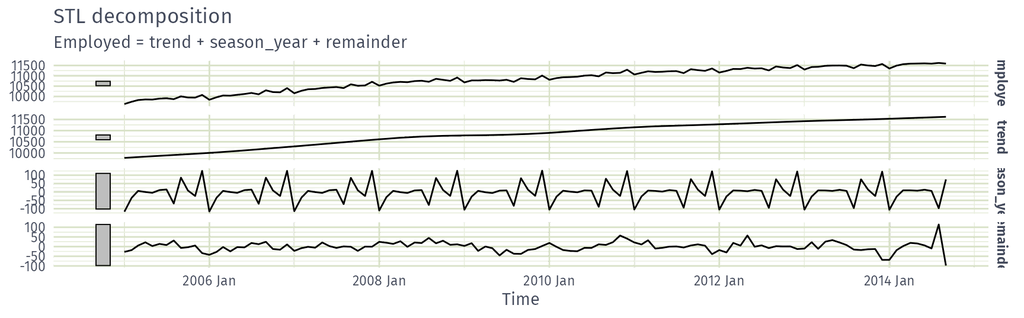

## The ABS stuff-up

```r
components(dcmp) |>
  filter(year(Time) == 2013) |>
  gg_season(season_year) +
  labs(title = "Seasonal component") + guides(colour = "none")
```

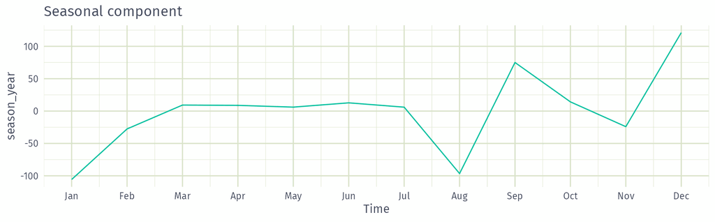

## The ABS stuff-up

```r
components(dcmp) |>
  as_tsibble() |>
  autoplot(season_adjust)
```

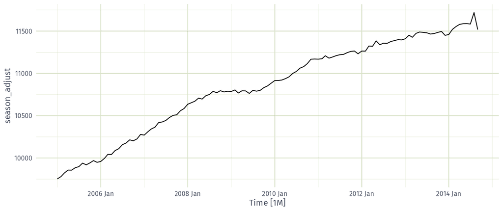

## The ABS stuff-up

- August 2014 employment numbers higher than expected.
- Supplementary survey usually conducted in August for employed people.
- Most likely, some employed people were claiming to be unemployed in August to avoid supplementary questions.
- Supplementary survey not run in 2014, so no motivation to lie about employment.
- In previous years, seasonal adjustment fixed the problem.
- The ABS has now adopted a new method to avoid the bias.